# PHY 481 Hw 6 - Andrew Koren

## 1. Gauss's law and cavities

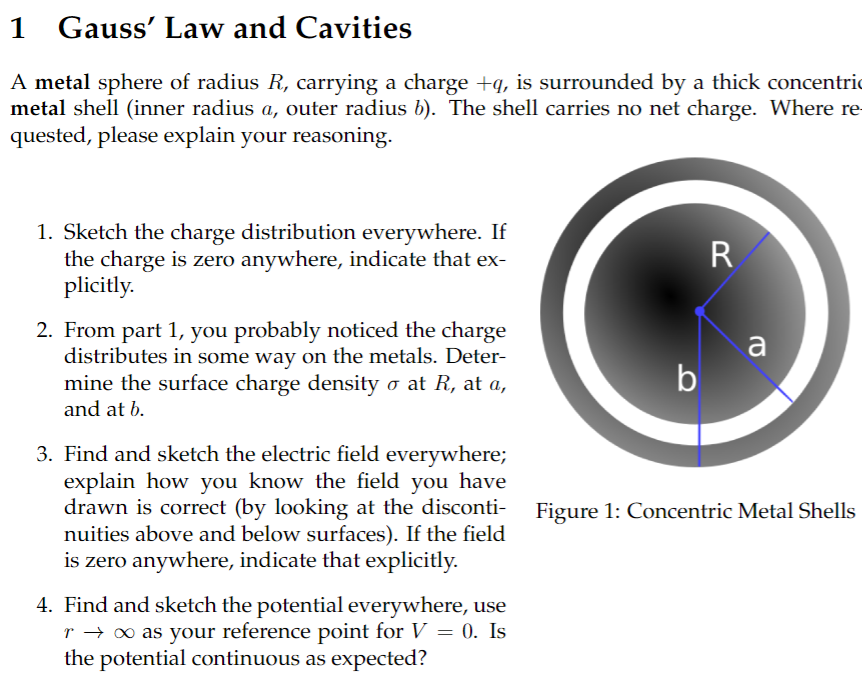

1. sketch

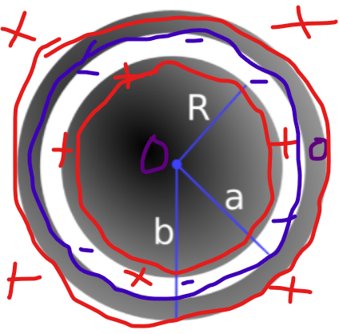

2. charge density

Total charge $+q$ is spread across the surface. Sphere surface area $= 4\pi r^2$

Sphere: $\sigma_R = \dfrac{+q}{4\pi R^2}$

Inside shell: $\sigma_a = \dfrac{-q}{4\pi a^2}$  
Outside shell: $\sigma_b = \dfrac{+q}{4\pi b^2}$

3. Electric field

$E$ inside conductor is always zero for our purposes. Use gauss's law to find E-fields outside conductors.

$$ \int_{\mathcal{S}} E \cdot da = Q_{enc}/\epsilon_0\\ E(r) = \begin{cases} 0 & r\leq R \\ \dfrac{+q}{4\pi r^2 \epsilon_0} & R < r < a \\ 0 & a \leq r\leq b \\ \dfrac{+q}{4\pi r^2 \epsilon_0} & r > b \\ \end{cases} $$

Sketch:

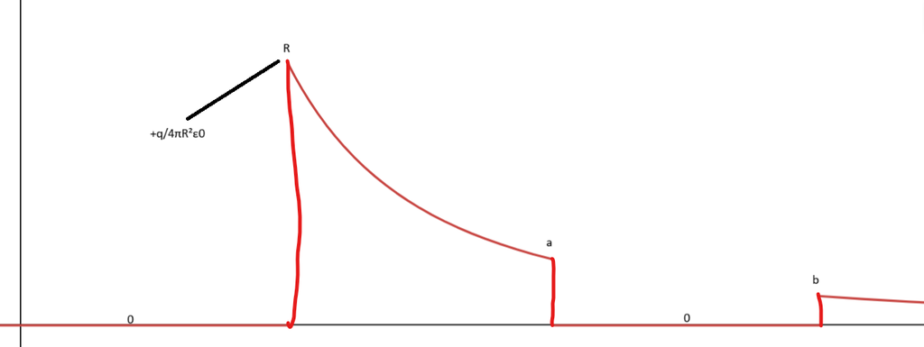

4. Voltage

$$ \Delta V = -\int E \cdot ds $$

The integral is multipart

$$ \int_\infty^{r>b} E_r dr = \frac{q}{4\pi \epsilon_0} \left. \left(-\frac{1}{r}\right) \right|_\infty^r =-\frac{q}{4\pi \epsilon_0 r} \\ \int_b^a E_r dr = 0 \\ \int_a^{r>R} E_r dr = \frac{q}{4\pi \epsilon_0} \left. \left(-\frac{1}{r}\right) \right|_a^r \\ =- \frac{q}{4\pi \epsilon_0 r} + \frac{q}{4\pi \epsilon_0 a} \\ \int_R^0 E_r dr = 0 $$

We have our $\Delta V$ for each case, so we can assemble them together with $V(\infty)=0$ to get our voltage function

$$ V(r) = \begin{cases} \frac{q}{4\pi \epsilon_0} \left(-\frac{1}{R} + \frac{1}{a} -\frac{1}{b} \right) & r\leq R\\ \frac{q}{4\pi \epsilon_0} \left(-\frac{1}{r} + \frac{1}{a} -\frac{1}{b} \right) & R<r<a\\ -\frac{q}{4\pi \epsilon_0 b} & a\leq r \leq b \\ -\frac{q}{4\pi \epsilon_0 r} & r>b\\ \end{cases} $$

Notice that $V(r)$ is continuous, and at $r=a$ the potential simplifies down to $-\frac{q}{4\pi \epsilon_0 b}$. Continuity is not disrupted by the charge densities, but the voltage function is not smooth

## 2. Coax capacitors

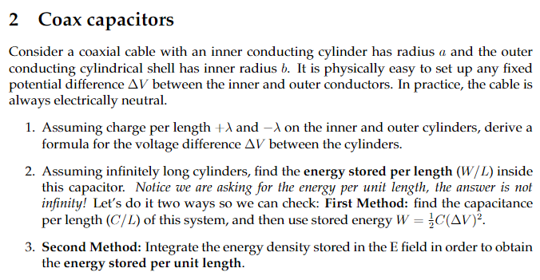

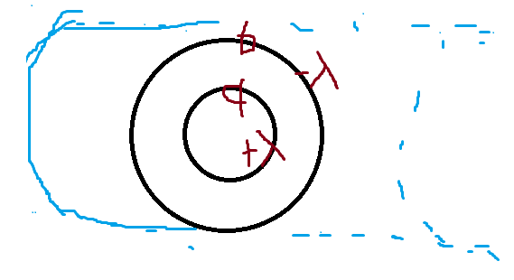

1. find $\Delta V$

Our result will be length-indepenedent. We can use the Poisson equation, but I'll just go through electric field first for old time's sake.

Using cylinder gaussian shells of length $L$ and radius $a<r<b$, we have

$$ \int E \cdot da = \frac{Q_{enc}}{\epsilon_0} \\ E_r 2\pi r l = \frac{\lambda l}{\epsilon_0} \quad \\ E(r) = \frac{\lambda}{2 \pi r \epsilon_0} $$

The boundaries $a$ and $b$ are used since this is where $Q_{enc} = \lambda l$. For $r<a$ there is no charge (it rests on the surface of the conductor), and for $r>b$ the charge enclosed from the two conductors cancels since they have the opposite magnitude linear density. Next is voltage

$$ \Delta V = V(b) - V(a) = -\int_a^b E(r) dr \\ = -\frac{\lambda}{2\pi \epsilon_0} \int_a^b \frac{1}{r} dr \\ = -\frac{\lambda}{2\pi \epsilon_0} \ln\left(\frac{a}{b} \right) \\ = \frac{\lambda}{2\pi \epsilon_0} \ln\left(\frac{b}{a} \right) $$

2. Energy method 1

Since $a<b$, the logarithm of $a/b$ is negative and $b/a$ is positive. The charge separated between the two conductors on segments of length $l$ are $\lambda l$, so capacitance is

$$ C = \frac{\lambda l}{\Delta V} = \frac{\lambda l * 2\pi \epsilon_0}{\lambda \ln\left(\frac{b}{a} \right)} = \frac{2\pi l \epsilon_0}{\ln\left(\frac{b}{a} \right)} $$ (Note: $C/l$ just remove $l$)

Capacitance should be dependent on the geometry of a capacitor, not total charge on the surface, so we're happy that $\lambda$ falls out here. Last is energy

$$ W = \frac{1}{2} C \left( \Delta V \right)^2 = \frac{\pi l \epsilon_0}{\ln\left(\frac{b}{a} \right)} \left(\frac{\lambda}{2\pi \epsilon_0} \ln\left(\frac{b}{a} \right)\right)^2 = l\frac{\lambda^2 \ln\left(\frac{b}{a}\right)}{4\pi \epsilon_0} \\ \frac{W}{l} = \frac{\lambda^2 \ln\left(\frac{b}{a}\right)}{4\pi \epsilon_0} $$

3. Straight from electric field

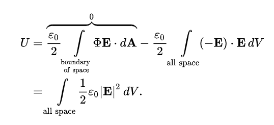

From wikipedia https://en.wikipedia.org/wiki/Electric_potential_energy

$$ W = \frac{1}{2} \epsilon_0 \int_V |E|^2 dV = \frac{2\pi l}{2} \epsilon_0 \int_a^b |E(r)|^2 rdr \\ = \frac{2\pi l}{2} \epsilon_0 \int_a^b \frac{\lambda^2}{4 \pi^2 r \epsilon_0^2}dr = \frac{\lambda^2l}{4\pi \epsilon_0} \int_a^b \frac{1}{r} dr = l\frac{\lambda^2 \ln\left(\frac{b}{a} \right)}{4 \pi \epsilon_0} \\ \frac{W}{l} = \frac{\lambda^2 \ln\left(\frac{b}{a} \right)}{4 \pi \epsilon_0} $$

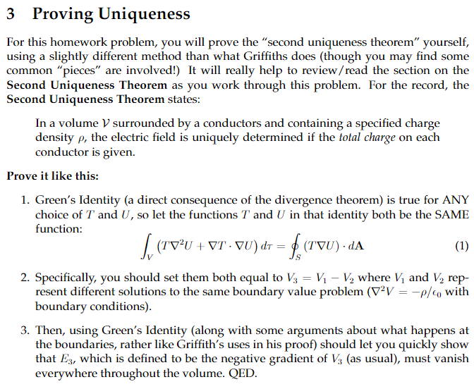

Proof.

We will show that for two solutions to the same BVP, $V_1$ and $V_2$, that the difference between the two $V_3 = V_1 - V_2 = 0$.

Since each potential depends on the same charge distribution and boundary conditions, we have

$$ \nabla^2 V_1 = \nabla^2 V_2 = -\frac{\rho}{\epsilon_0} $$

so the laplacian of $V_3$ is

$$ \nabla^2 V_3 = \nabla^2\left(V_1 - V_2 \right) = -\frac{\rho}{\epsilon_0} + \frac{\rho}{\epsilon_0} = 0 $$

According to Green's identity, we can find the relationship between the volume integral of two arbitrary scalar potentials and the surface integral of the two as

$$ \int_V \left( T\nabla^2 U + \nabla T \cdot \nabla U\right)d\tau = \oint_S \left( T\nabla U \right) \cdot dA $$

Using $T=U=V_3$, this gives us

$$ \int_V \left(V_3 \nabla^2 V_3 + |\nabla V_3|^2 \right) d\tau = \oint_S\left( V_3 \nabla V_3\right) \cdot dA \\ \rightarrow \int_V |\nabla V_3|^2 d\tau = \oint_S\left( V_3 \nabla V_3\right) \cdot dA $$

Since $V_1$ and $V_2$ fit the same boundary conditions, they are equivalent on any surface. As such $$ \oint_S\left( V_3 \nabla V_3\right) \cdot dA = 0 \\ \rightarrow \int_V |\nabla V_3|^2 d\tau = 0 $$

Since $|\nabla V_3|^2$ is always positive, $V_3=0$ is necessary for this integral to be true as any value $V_3 \neq 0$ would result in some contribution to the volume integral. Thus $V_1$ and $V_2$ are equivalent. QED